# Module 9: Goodness of Fit

Author

Affiliation

Adam Spiegler

University of Colorado Denver

## Additional Reading

- [Section 3.10 Evaluating model fit](https://jfrench.github.io/LinearRegression/linear-model-estimation.html) from *A Progressive Introduction to Linear Models*
- Chapter 5 of *Linear Regression Models: Applications in R* ([link to library ebook](https://go.exlibris.link/69jsQwWW))
- Sections 3.4.6 and 4.5 of *Applied Linear Regression* ([link to library ebook](https://go.exlibris.link/69jsQwWW))

# Loading Required Packages

```r
library(tidyverse)
library(wooldridge)  # to access hprice2 data
```

# A Review of Multiple Linear Regression Models

## The Model

A **multiple linear regression** model is a linear regression model with more than one predictor $X_i$ and a single response variable $Y$. In general, we include an intercept term as a predictor, so if there are $p-1$ predictor variables, our model has $p$ regression coefficients. The most common multiple linear regression model is

$$Y = \beta_0 + \beta_1 X_1 + \beta_2 X_2 + \ldots + \beta_{p-1} X_{p-1} + \epsilon .$$

## Error Assumptions

1. The errors $\epsilon_i$ have **mean zero, $E(\epsilon_i) = 0$** for all $i$. On average, predictions are accurate.
2. The errors are **normally distributed**. Most of the time the observed values are close to the predicted. Observed values are less likely farther away from the line.
3. The errors all have the same, **constant variance (homoscedascity)**. Predictions are equally accurate everywhere.
4. The **errors are uncorrelated**. The amount of error in a prediction is independent of the errors of any other predictions.
5. **Collinearity**: No combination of predictors has a perfect association. For example, one predictor is not a scalar multiple of another.

We can restate error assumptions (1)-(4) as:

$$\large \epsilon_i \sim N(0, \sigma^2) \qquad \text{and} \qquad \text{Cov}(\epsilon_i, \epsilon_j) = 0 \ \ \text{ if } i \ne j.$$

In addition to the error assumptions, we also assume the mean value of each $Y_i$ is a linear function of the predictors.

$$\bar{Y}_i = E(Y_i | X) = E(\beta_0 + \beta_1 x_1 + \ldots \beta_{p-1} x_p + \epsilon_i) = \beta_0 + \beta_1 x_1 + \ldots \beta_{p-1} x_p$$

### Estimating the Variance of the Errors

The errors $\boldsymbol{\epsilon}$ are unknown random variables, but we assume the are i.i.d. (identically and independently distribution). We can estimate the distribution $\epsilon_i$ with distribution of all observed residuals, $\hat{\epsilon}_i = y_i - \hat{y}_i$.

The OLS estimator for $\text{Var} (\boldsymbol{\epsilon})$ is given by

$$\hat{\boldsymbol\sigma}^2 = \frac{ \boldsymbol{\hat{\epsilon}}^T \boldsymbol{\hat{\epsilon}} }{n-p} = \frac{ \text{RSS} }{n-p} .$$

## Properties of OLS Estimator: The Gauss-Markov Theorem

If $\mathbf{X}$ and $\mathbf{y}$ denote the model matrix and observed values of the response. The OLS estimator for the regression coefficients is

$$\boldsymbol{\hat{\beta}} = \left( \mathbf{X}^T \mathbf{X} \right)^{-1} \mathbf{X}^T \mathbf{y}$$
We can express solution to OLS equivalently as the solution to a matrix equation

$$\mathbf{X} \boldsymbol{\hat{\beta}} = \mathbf{H} \mathbf{y} , \qquad \mathbf{R} \boldsymbol{\hat{\beta}} = \mathbf{Q}^T \mathbf{y} , \quad \text{or} \quad \boldsymbol{\hat{\beta}} = \mathbf{V} \mathbf{\Sigma}^{-1} \mathbf{U}^T \mathbf{y} .$$

There are three key reasons why the OLS estimator for $\boldsymbol{\beta}$ is most commonly used:

1. They make sense geometrically. It results in the orthogonal projection onto the model space (spanned by the column space of $\mathbf{X}$). The **hat matrix** $\mathbf{H} = \mathbf{X} \left( \mathbf{X}^T \mathbf{X} \right)^{-1} \mathbf{X}^T$ projects $\mathbf{y}$ into the plane the minimizes the RSS.
2. If the error assumptions are satisfied, then the OLS estimator is equal to the Maximum Likelihood Estimator (MLE).
3. The OLS estimator is the **Best Linear Unbiased Estimator (BLUE)** of $\boldsymbol{\beta}$. The ordinary least squares estimator $\boldsymbol{\hat{\beta}}$ is an **unbiased estimator** and **most efficient** estimator for $\boldsymbol{\beta}$.

## Other Estimators for $\boldsymbol{\beta}$.

We are going to use the OLS estimator when constructing linear regression models due to the properties above. There are other methods that may be preferred under special circumstances.

- **Generalized least squares (GLS)** regression is used when the errors are correlated.
- **Ridge** and **Lasso** regression may be preferred with regressors that are highly correlated or when the data has many features.
  - A regularization term is added to the standard loss function to prevent overfitting and multicollinearity.
  - Regressors with coefficients close to 0 are eliminated.
  - Preference for including less regressors in the model.
  - They result in simpler, more interpretable models
- We can use **resampling methods** when the normality assumption for the errors is not satisfied.

# Measurements of Association

**Covariance** measures how strong is the dependence between two variables

$$\mbox{Cov}(X,Y) = E\bigg( (X-\mu_X)(Y-\mu_Y) \bigg) .$$

- If $\mbox{Cov}(X,Y) > 0$ increasing $X$ leads to larger values of $Y$.
- If $\mbox{Cov}(X,Y) < 0$ increasing $X$ leads to smaller values of $Y$.

The defect of covariance is that its computed value depends critically on the units of measurement. Ideally, the choice of units should have no effect on a measure of strength of relationship. This is achieved by scaling the covariance.

The **correlation coefficient** of $X$ and $Y$ denoted by $\mbox{Cor}(X,Y)$ or $\rho_{X,Y}$ (often just $\rho$) is defined by

$$\rho_{X,Y} = \frac{\mbox{Cov}(X,Y)}{\sigma_X \cdot \sigma_Y} .$$

The correlation coefficient satisfies the following properties:

- If $X$ and $Y$ are independent, then $\rho = 0$. However, if $\rho =0$ then it does not follow that $X$ and $Y$ must be independent.
- If $\rho =1$ or $\rho = -1$, then $Y=\beta_0 + \beta_1X$ is perfectly linear.

## Question 1

Suppose we want to approximate the average wind speed of a storm in the North Atlantic. We have gathered a data set `storms` that includes about 20,000 observations of storms in the North Atlantic from 1975-2022.

```r
data(storms)  # loads storms
summary(storms$wind)
```

```
   Min. 1st Qu.  Median    Mean 3rd Qu.    Max.
  10.00   30.00   45.00   50.05   65.00  165.00
```

### Question 1a

If we do not know any additional information about any features of a storm in the North Atlantic, what would be a reasonable estimate for its wind speed?

#### Solution to Question 1b

### Question 1c

Which estimate do you believe is more accurate? Why?

#### Solution to Question 1c

# The Coefficient of Determination, $R^2$

A common measure of goodness of fit is **$R^2$, the coefficient of determination** (or percentage of variance explained), given by

$$R^2=1- \frac{\sum (Y_i - \widehat{Y}_i)^2}{\sum (Y_i - \overline{Y})^2} =1- \frac{\mbox{RSS}}{\mbox{TSS}}= \frac{\mbox{SS}_{\rm reg}} {\mbox{TSS}} = \mbox{Cor}^2(\mathbf{y}, \hat{\mathbf{y}}) .$$

Where we have:

$\mbox{RSS} = \sum (Y_i - \widehat{Y}_i)^2$ is the **Residual Sum of Squares (RSS)**.

- RSS measures the variability in our response that **is NOT explained by our model**.

$\mbox{TSS} = \sum (Y_i - \overline{Y})^2$ is the **Total Sum of Squares correct for the mean (TSS)**.

- TSS measures the **total variability in the response**.
- It is RSS from the constant mean model $Y = \beta_0 + \epsilon$.

$\mbox{SS}_{\rm reg} = \sum (\widehat{Y}_i - \overline{Y})^2 = \mbox{TSS} - \mbox{RSS}$ is the **regression sum of squares**.

- $\mbox{SS}_{\rm reg}$ is the part of the total variation in the response that **is explained by our model**.

Three quantities are related with the equation

$$\mbox{TSS} = \mbox{RSS} + \mbox{SS}_{\rm reg} .$$

**Warning**

The notation for these terms is not consistent (sorry). For example,

- We use RSS for the residual sum of squares.
  - This is consistent with books by French and Weisberg.
  - Hoffman uses the notation SSE instead (sum of squared errors).
- We use $\mbox{SS}_{\rm reg}$ to denote the regression sum of squares.
  - This is consistent with books by French and Weisberg.
  - Hoffman’s book uses for the regression sum of squares which is easily confused with how we use RSS for residual sum of squares.
  - Hoffman’s use of the notation RSS for $\mbox{SS}_{\rm reg}$ is not standard and can be confusing.
- At least TSS is used by all to represent the total sum of squares!

## Question 2

We explore $R^2$ using the `wooldridge` package that contains a data frame named `hprice2` with 506 observations from small geographic areas in the U.S. We include the following variables in our analysis (and excluded others) that we store to a data frame named `house`:

- `price`: median housing price, $
- `crime`: crimes committed per capita
- `rooms`: avg number of rooms
- `stratio`: average student-teacher ratio
- `lowstat`: percentage of classified as lower economic status

Run the code cell below to store the data to the `house` and display a correlation matrix for the data frame.

```r
#library(wooldridge)
house <- select(hprice2, c(price, crime, rooms, stratio, lowstat))
round(cor(house), 4)
```

```
          price   crime   rooms stratio lowstat
price    1.0000 -0.3879  0.6958 -0.5033 -0.7264
crime   -0.3879  1.0000 -0.2188  0.2887  0.4470
rooms    0.6958 -0.2188  1.0000 -0.3540 -0.6096
stratio -0.5033  0.2887 -0.3540  1.0000  0.3654
lowstat -0.7264  0.4470 -0.6096  0.3654  1.0000
```

**Warning**

If you have not installed the `wooldridge` package, be sure to run the command `install.packages("wooldridge")` in the console. You may also need to run `library(wooldridge)` if you have not run the first code cell in this document.

### Question 2a

Construct a linear model using the sample data now stored in `house` with `price` as the response and `rooms` as the predictor. Store the output to `price_lmod` and display just the $R^2$ value of the model on screen.

#### Solution to Question 2a

### Question 2b

What is the value of the RSS of the model? Display the value on screen and store it.

#### Solution to Question 2b

### Question 2c

What is the value of the TSS of the model? Display the value on screen and store it.

#### Solution to Question 2c

### Question 2d

What is the value of the $\text{SS}_{\rm{reg}}$? Display the value on screen and store it.

#### Solution to Question 2d

### Question 2e

Use the values you have previously stored to confirm $\mbox{TSS} = \mbox{RSS} + \mbox{SS}_{\rm reg}$ for this model.

#### Solution to Question 2e

### Question 2f

Use the values you have previously stored to confirm the $R^2$ value you found in part (a).

#### Solution to Question 2f

# Interpreting the $R^2$ Value

Some comments about the coefficient of determination:

$$R^2 = 1- \frac{\mbox{RSS}}{\mbox{TSS}}= \frac{\mbox{SS}_{\rm reg}} {\mbox{TSS}} = \mbox{Cor}^2(\mathbf{y}, \hat{\mathbf{y}}) .$$

- $R^2$ is the proportion of the total variability in the response that is explained by our model.
- $0 \leq R^2 \leq 1$
- $R^2 = 1$ for a linear model that perfectly fits the data.
- Generally, larger values of $R^2$ suggest the model explains more of the variability in the response.
- The multiple $R^2$ value is displayed in the `summary()` of a `lm` object.
- `summary(lmod)$r.squared` will extract the $R^2$ value of an `lm` object

**Note**

The adjusted $R^2$ value that also appears in the `summary()` output of an `lm` object is a penalty for adding unnecessary variables. We will discuss this adjustment later.

## A Graphical Interpretation of $R^2$

Suppose we want to predict the value of the response $Y$:

- If we do not know values for the predictor(s), the best approximation is $\bar{Y}$.
  - The variability of this prediction is high since the variability of $Y$ is high.
  - This is represented with the long solid arrow
- If we do know value(s) for the predictor(s), the prediction is given by the regression line.
  - The prediction is less variable assuming there is some linear association between $Y$ and $X$.
  - This variability is represented by the shorter, dashed arrow.

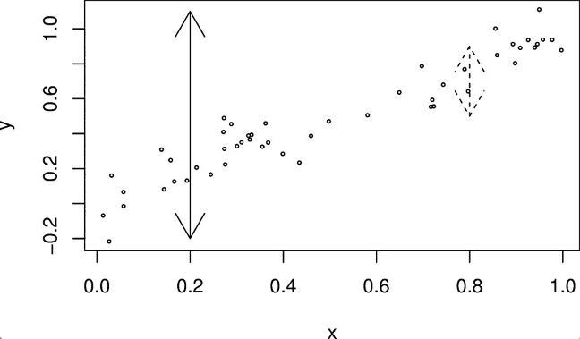

Graphical Interpretation of R-squared

## Question 3

Rank the plots below from greatest to smallest $R^2$ value. What do you think the approximate $R^2$ values are for each plot?

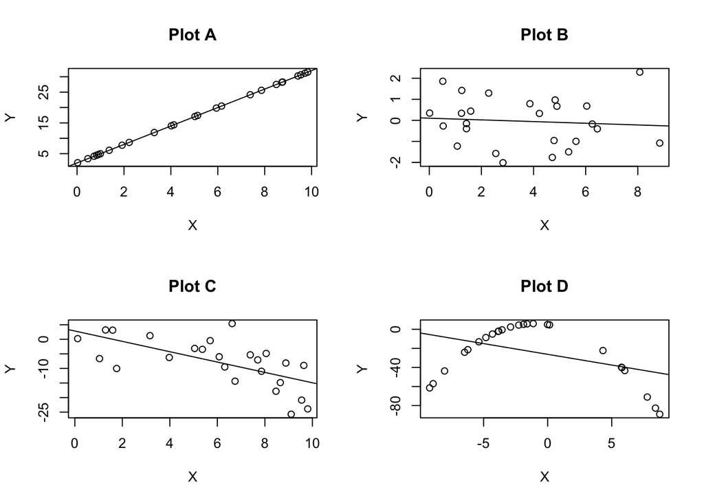

### Solution to Question 3

**Tip**

That was fun! Try some out on your own http://istics.net/Correlations/ .

## Question 4

Each of the four linear models have approximately the same intercept $\hat{\beta}_0 \approx 3$, slope $\hat{\beta}_1 \approx 0.5$, and $R^2 \approx 0.67$. Do you believe the linear model $\hat{y} = 3 + 0.5x$ fits all four data sets equally well? Why or why not?

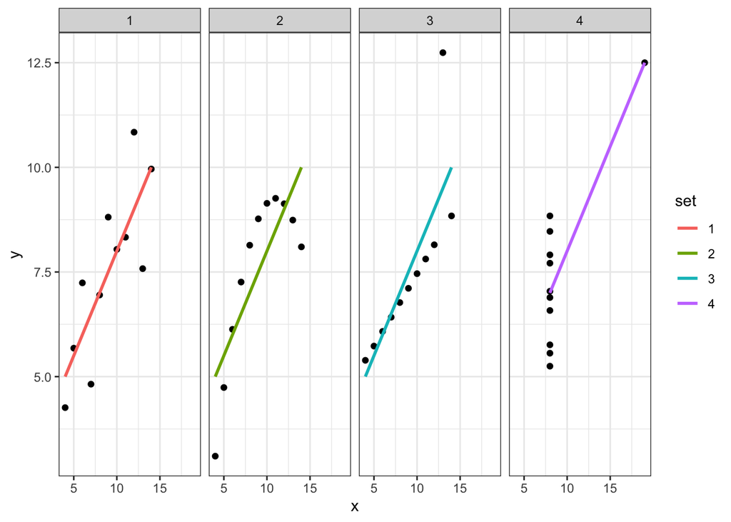

### Solution to Question 4

## A Caution with $R^2$

It may seem sensible to choose between models based on the value of  
$R^2$, but you should avoid this misconception:

1. $R^2$ never decreases as regressors are added to an existing model. Basically, we can increase $R^2$ by simply adding more and more regressors to our existing model, even if they are nonsensical and make the model more difficult to interpret.
2. $R^2$ doesn’t tell us whether a model adequately describes the pattern of the observed data. $R^2$ is a useful statistic for measuring model fit when there is approximately a *linear* relationship between the response values and fitted values.

In Question 2a, we found the $R^2$ value for the linear model for `price` based on the predictor `rooms` is $R^2=0.4841$

In the code cell below we add a variable `junk` to our model which is literally a bunch (the same number as the number of observations in `house`) of randomly selected values from the standard normal distribution that have absolutely nothing to do with housing prices.

```r
set.seed(29) # for reproducibility
n_price <- length(house$price)
junk <- rnorm(n_price)
silly_lmod <- update(price_lmod, . ~ . + junk)
summary(silly_lmod)$r.squared
```

```
[1] 0.4896669
```

By adding an additional variable with no information, the $R^2$ increased to $0.4897$.

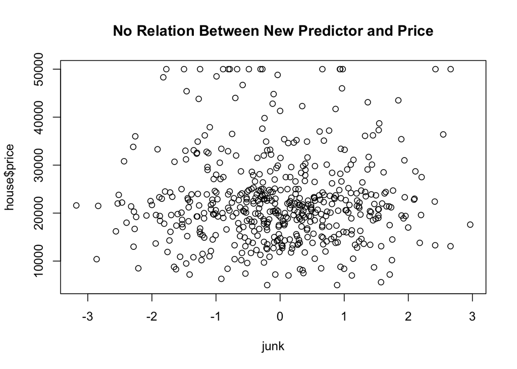

```r
plot(junk, house$price,
     main = "No Relation Between New Predictor and Price")
```

## Question 5

403 African Americans were interviewed in a study to understand the prevalence of obesity, diabetes, and other cardiovascular risk factors in central Virginia. The `diabetes` data are in the `faraway` package. Run `?diabetes` for more info.

```r
data(diabetes, package = "faraway")
glimpse(diabetes)
```

```
Rows: 403
Columns: 19
$ id       <labelled> 1000, 1001, 1002, 1003, 1005, 1008, 1011, 1015, 1016, 10…
$ chol     <labelled> 203, 165, 228, 78, 249, 248, 195, 227, 177, 263, 242, 21…
$ stab.glu <labelled> 82, 97, 92, 93, 90, 94, 92, 75, 87, 89, 82, 128, 75, 79,…
$ hdl      <labelled> 56, 24, 37, 12, 28, 69, 41, 44, 49, 40, 54, 34, 36, 46, …
$ ratio    <labelled> 3.6, 6.9, 6.2, 6.5, 8.9, 3.6, 4.8, 5.2, 3.6, 6.6, 4.5, 6…
$ glyhb    <labelled> 4.31, 4.44, 4.64, 4.63, 7.72, 4.81, 4.84, 3.94, 4.84, 5.…
$ location <fct> Buckingham, Buckingham, Buckingham, Buckingham, Buckingham, B…
$ age      <int> 46, 29, 58, 67, 64, 34, 30, 37, 45, 55, 60, 38, 27, 40, 36, 3…
$ gender   <fct> female, female, female, male, male, male, male, male, male, f…
$ height   <int> 62, 64, 61, 67, 68, 71, 69, 59, 69, 63, 65, 58, 60, 59, 69, 6…
$ weight   <int> 121, 218, 256, 119, 183, 190, 191, 170, 166, 202, 156, 195, 1…
$ frame    <fct> medium, large, large, large, medium, large, medium, medium, l…
$ bp.1s    <labelled> 118, 112, 190, 110, 138, 132, 161, NA, 160, 108, 130, 10…
$ bp.1d    <labelled> 59, 68, 92, 50, 80, 86, 112, NA, 80, 72, 90, 68, 80, NA,…
$ bp.2s    <labelled> NA, NA, 185, NA, NA, NA, 161, NA, 128, NA, 130, NA, NA, …
$ bp.2d    <labelled> NA, NA, 92, NA, NA, NA, 112, NA, 86, NA, 90, NA, NA, NA,…
$ waist    <int> 29, 46, 49, 33, 44, 36, 46, 34, 34, 45, 39, 42, 35, 37, 36, 3…
$ hip      <int> 38, 48, 57, 38, 41, 42, 49, 39, 40, 50, 45, 50, 41, 43, 40, 4…
$ time.ppn <labelled> 720, 360, 180, 480, 300, 195, 720, 1020, 300, 240, 300, …
```

We will consider the relationship between cholesterol and several of the predictors.

- Regress total cholesterol on stabilized glucose, high density lipoprotein, glycosolated hemoglobin, age, gender, height, weight, waist size, and hip size.
- Determine the equation for the fitted model.
- What is the fitted value for the third observation?
- Plot the residuals versus fitted values. Are there any unusual residuals? Do the error assumptions seem valid?
- How much response variation does the model explain? Is this a meaningful measure of model fit? Explain why or why and you may use additional plots to support your answer.

### Solution to Question 5

# Appendix: Useful Functions with `lm()`

Some useful commands working with `lm`:

- `coef(lmod)` returns the values of the regression coefficients.
- `x <- model.matrix( ~ x1 + x2 + x3 + x4, data = data.frame)` creates matrix $\mathbf{X}$.
- `y <- data.frame$response_var` creates vector of observed values of $\mathbf{y}$.
- `residuals(lmod)` vector of residuals $\hat{\boldsymbol\epsilon}$.
- `deviance(lmod)` computes the RSS of the linear model.
- `df.residual(lmod)` computes the degrees of freedom $n-p$.
- `sigma(lmod)` computes the estimate for the standard error $\hat{\sigma}$.
- `summary(lmod)$r.squared` gives $R^2$ value.
- `summary(lmod)$adj.r.squared` gives the adjusted $R^2$ value.
- `names(lmod)` lists quantities we can extract from the `lmod`.
- `vcov(lmod)` estimated covariance matrix of the regression coefficients.